# Tutorial: Qualitative structure of a discrete-time Markov chain

When is the stationary distribution meaningful? When can a learner get from A to B? When do they get stuck?

## What this tutorial answers

`passage_time()` and `markov_stability()` both return a stationary distribution and use it as the basis for every per-state metric they report. That is only meaningful if the underlying chain has *one* long-run distribution to converge to — which is to say, if the chain is **regular** (irreducible plus aperiodic). When it is not, the reported `stationary_prob` is averaging across distinct behavioural phases that the learner never actually mixes between. `chain_structure()` is the diagnostic that tells you which case you are in.

It also answers two interpretive questions that come up every time a coded sequence dataset has a clear terminal behaviour (“submitted”, “abandoned”, “gave up”): which states *funnel* into which, and how long does the funnel take.

This tutorial walks through `chain_structure()` on four bundled datasets:

- `trajectories` — engagement states (Active / Average / Disengaged).
- `group_regulation_long` — collaborative-regulation actions across 27,533 events, six courses, two achievement strata.
- `ai_long` — AI-coded vibe-coding interaction sessions.
- `human_long` — the same sessions coded by a human rater.

Every section follows the same shape: state the question, run a single `Nestimate` call, read the printed result, draw a conclusion.

## What `chain_structure()` returns

```r
P <- matrix(c(
  0.5, 0.3, 0.2,
  0.4, 0.4, 0.2,
  0.0, 0.0, 1.0
), nrow = 3, byrow = TRUE,
   dimnames = list(c("Working", "Distracted", "GivenUp"),
                   c("Working", "Distracted", "GivenUp")))
chain_structure(P)
```

```
#> Chain structure  [3 states]
#>   irreducible: FALSE   aperiodic: TRUE   regular: FALSE   reversible: NA
#>   classes: 2  (recurrent: 1, transient: 1)
#>   absorbing states: GivenUp
#>
#> State classification:
#>     Working  Distracted     GivenUp
#> "transient" "transient" "absorbing"
#>
#> Period (recurrent states):
#> GivenUp
#>       1
#>
#> Absorption probabilities (transient -> absorbing):
#>            GivenUp
#> Working          1
#> Distracted       1
#>
#> Mean absorption time (steps from transient state):
#>    Working Distracted
#>          5          5
```

The header summarises four chain-level questions: is the chain irreducible (one communicating class)? aperiodic? regular (= both)? does it satisfy detailed balance against its stationary distribution? Below that, every state is classified as **absorbing**, **recurrent**, or **transient**, and — when absorbing states exist — the absorption probabilities and expected absorption times tell you what happens to the transient states.

In this synthetic example, GivenUp is absorbing (`P[GivenUp, GivenUp] = 1`) and the other two are transient: every learner eventually gives up, taking five steps on average from either Working or Distracted. The chain is *not* regular because there is no return path from GivenUp; running `markov_stability(P)` here would report a stationary distribution concentrated entirely on GivenUp, which is correct as a long-run statement but uninformative about how long Working and Distracted persist before absorption — that information lives in `mean_absorption_time`, not `stationary_prob`.

The `plot()` method renders the hitting-probability matrix with rows and columns ordered by communicating class, so the block structure of the chain is visible at a glance. Axis labels are coloured by classification (absorbing in vermillion, recurrent in blue, transient in orange).

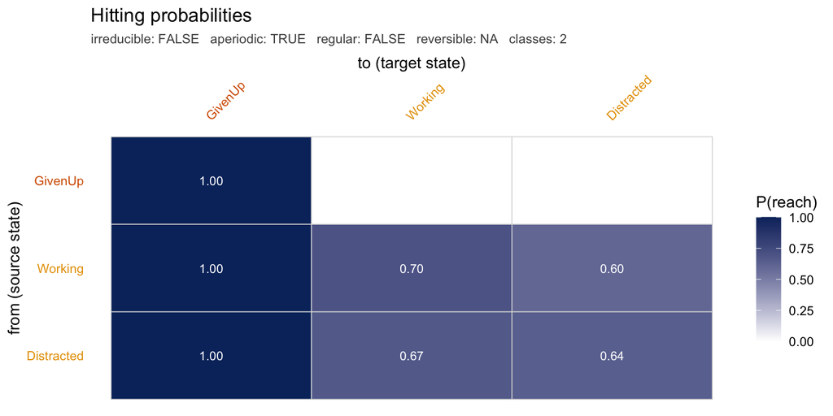

```r
plot(chain_structure(P))
```

Reading the heatmap: the **GivenUp** column is solid dark — every state, including itself, reaches GivenUp with probability 1. The **GivenUp** row is white except in the GivenUp column — once you are in GivenUp, you cannot reach Working or Distracted. That asymmetry is the visual signature of an absorbing state.

The remainder of the tutorial uses `chain_structure()` as a *precondition check* on real data, then reads off the per-state absorption and hitting structure where it applies.

## Engagement trajectories

The `trajectories` dataset records 138 students’ engagement states across 15 weekly time points. The three states are coarse: Active, Average, Disengaged. The first analytic question is whether transitions between these states form a regular chain; if so, `markov_stability()`’s long-run output is interpretable; if not, we need a different reading.

```r
net_traj <- build_network(as.data.frame(trajectories), method = "relative")
cs_traj  <- chain_structure(net_traj)
cs_traj
```

```
#> Chain structure  [3 states]
#>   irreducible: TRUE   aperiodic: TRUE   regular: TRUE   reversible: FALSE
#>   classes: 1  (recurrent: 1, transient: 0)
#>
#> State classification:
#>      Active     Average  Disengaged
#> "recurrent" "recurrent" "recurrent"
#>
#> Period (recurrent states):
#>     Active    Average Disengaged
#>          1          1          1
```

The chain is irreducible, aperiodic, regular, and not reversible. Every state is recurrent — no engagement category is a one-way door. The *non-reversibility* is the substantive finding here: it says students do not flow symmetrically between the three states. There is a preferred direction in the long-run flux, even though every state is recurrent.

Because the chain is regular, `markov_stability()` can be reported without further hedging:

```r
markov_stability(net_traj)
```

```
#> Markov Stability Analysis
#>
#>       state persistence stationary_prob return_time sojourn_time
#>      Active      0.6976          0.3719        2.69         3.31
#>     Average      0.6099          0.4431        2.26         2.56
#>  Disengaged      0.4831          0.1850        5.41         1.93
#>  avg_time_to_others avg_time_from_others
#>                6.99                 5.84
#>                6.74                 3.20
#>                4.47                 9.16
```

The hitting probabilities are saturated:

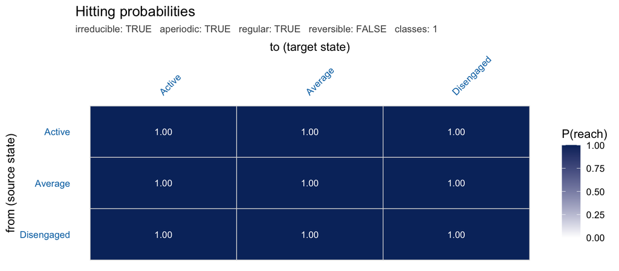

```r
plot(cs_traj)
```

Every state can reach every other with probability 1 — the heatmap is saturated dark across all 9 cells. With three recurrent states and no absorbing endpoint, the educational interpretation is straightforward: students cycle between engagement levels for the duration of the course, and the long-run average stationary distribution genuinely describes the population.

## Group regulation actions

```r
net_gr <- build_network(group_regulation_long,
                        action = "Action",
                        actor  = "Actor",
                        time   = "Time",
                        method = "relative")
cs_gr <- chain_structure(net_gr)
cs_gr
```

```
#> Chain structure  [9 states]
#>   irreducible: TRUE   aperiodic: TRUE   regular: TRUE   reversible: FALSE
#>   classes: 1  (recurrent: 1, transient: 0)
#>
#> State classification:
#>       adapt    cohesion   consensus  coregulate     discuss     emotion
#> "recurrent" "recurrent" "recurrent" "recurrent" "recurrent" "recurrent"
#>     monitor        plan   synthesis
#> "recurrent" "recurrent" "recurrent"
#>
#> Period (recurrent states):
#>      adapt   cohesion  consensus coregulate    discuss    emotion    monitor
#>          1          1          1          1          1          1          1
#>       plan  synthesis
#>          1          1
```

The chain is irreducible, aperiodic, regular, and *not* reversible. Substantively, the regularity finding says every regulation action is reachable from every other and there are no absorbing behaviours — if some single action had been a dead-end (for example “disengage” or “exit”), it would warrant a separate funnel analysis. The fact that none is absorbing means `markov_stability()` reads directly as a portrait of the population.

Non-reversibility is the substantively important finding. It says the flux between any pair of regulation actions is asymmetric at equilibrium: the rate of transitions from action *i* to *j* differs from the rate from *j* to *i*. There *is* a preferred direction through the regulation behaviours — collaborative regulation is a sequenced process, not a memoryless mix of marginally-preferred actions. The next question, then, is whether the *direction* of that sequence differs between high and low achievers.

```r
net_gr_grp <- build_network(group_regulation_long,
                            action = "Action",
                            actor  = "Actor",
                            time   = "Time",
                            group  = "Achiever",
                            method = "relative")
cs_high <- chain_structure(net_gr_grp$High)
cs_low  <- chain_structure(net_gr_grp$Low)

data.frame(
  group         = c("High", "Low"),
  irreducible   = c(cs_high$is_irreducible, cs_low$is_irreducible),
  aperiodic     = c(cs_high$is_aperiodic,   cs_low$is_aperiodic),
  regular       = c(cs_high$is_regular,     cs_low$is_regular),
  reversible    = c(cs_high$is_reversible,  cs_low$is_reversible),
  n_classes     = c(length(cs_high$communicating_classes),
                    length(cs_low$communicating_classes)),
  stringsAsFactors = FALSE
)
```

| group | irreducible | aperiodic | regular | reversible | n_classes |
| --- | --- | --- | --- | --- | --- |
| High | TRUE | TRUE | TRUE | FALSE | 1 |
| Low | TRUE | TRUE | TRUE | FALSE | 1 |

Both strata produce regular non-reversible chains with one communicating class — the qualitative chain structure is identical. The substantive difference between high and low achievers, if any, is therefore in the quantitative parameters (transition probabilities, dwell times, stationary frequencies), not in the *qualitative* shape of the regulation process. That is exactly the question `passage_time()` on each group answers, and it is exactly the question that would be *meaningless* if the two chains had different qualitative structure.

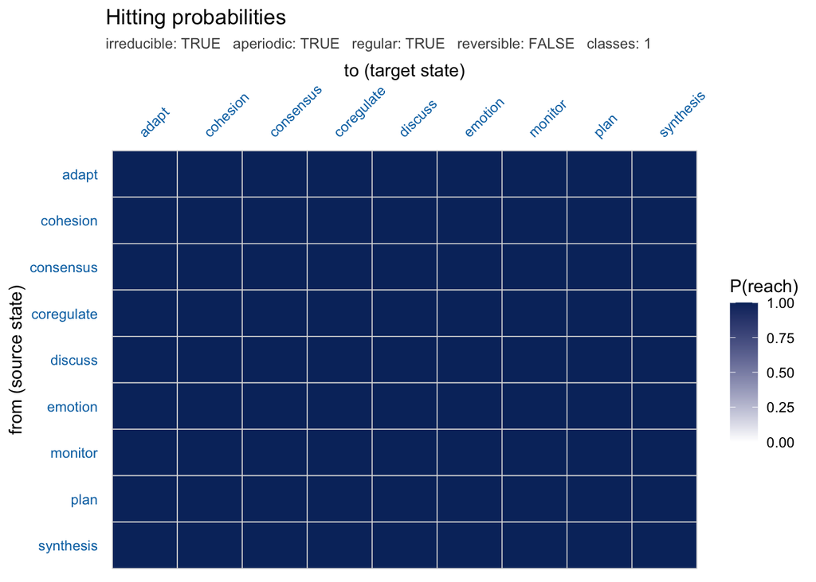

```r
plot(cs_high, show_values = FALSE)
```

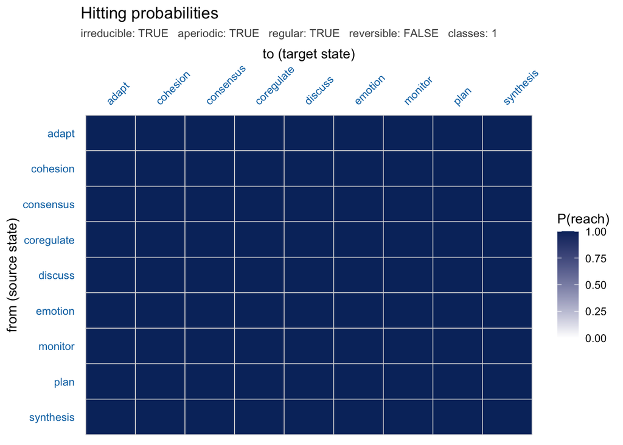

```r
plot(cs_low, show_values = FALSE)
```

## Vibe-coding interactions: AI- vs human-coded

The `ai_long` and `human_long` datasets code 429 vibe-coding sessions into a small set of cluster categories (three at the coarsest level used here). The two coders disagree on the boundary of nearly every category, but the question for `chain_structure()` is coarser: do they agree on the *qualitative* structure of the resulting chain?

```r
net_ai    <- build_network(ai_long,    action = "cluster",
                           actor = "session_id", time = "code_order",
                           method = "relative")
net_human <- build_network(human_long, action = "cluster",
                           actor = "session_id", time = "code_order",
                           method = "relative")
cs_ai    <- chain_structure(net_ai)
cs_human <- chain_structure(net_human)

data.frame(
  coder       = c("AI", "Human"),
  n_states    = c(length(cs_ai$states), length(cs_human$states)),
  irreducible = c(cs_ai$is_irreducible, cs_human$is_irreducible),
  aperiodic   = c(cs_ai$is_aperiodic,   cs_human$is_aperiodic),
  regular     = c(cs_ai$is_regular,     cs_human$is_regular),
  reversible  = c(cs_ai$is_reversible,  cs_human$is_reversible),
  absorbing   = c(length(cs_ai$absorbing_states),
                  length(cs_human$absorbing_states)),
  stringsAsFactors = FALSE
)
```

| coder | n_states | irreducible | aperiodic | regular | reversible | absorbing |
| --- | --- | --- | --- | --- | --- | --- |
| AI | 3 | TRUE | TRUE | TRUE | FALSE | 0 |
| Human | 3 | TRUE | TRUE | TRUE | FALSE | 0 |

The two coding schemes produce qualitatively identical chains: regular, non-reversible, no absorbing states. So even though raters disagree on which utterance maps to which category, they agree on the topological shape of the conversational process. That is a stronger inter-rater guarantee than category-level agreement statistics provide.

Non-reversibility for both says the same thing it said for `trajectories`: there is a preferred direction in the long-run flow between behaviours. Coding sessions move forward, not symmetrically.

```r
cmp <- data.frame(
  cluster   = cs_ai$states,
  H_self_ai = round(diag(cs_ai$hitting_probabilities), 3),
  stringsAsFactors = FALSE
)
cmp$H_self_human <- round(diag(cs_human$hitting_probabilities)[match(cmp$cluster, cs_human$states)], 3)
cmp$delta <- round(cmp$H_self_ai - cmp$H_self_human, 3)
cmp[order(-abs(cmp$delta)), ]
```

|  | cluster | H_self_ai | H_self_human | delta |
| --- | --- | --- | --- | --- |
| Action | Action | 1 | NA | NA |
| Communication | Communication | 1 | NA | NA |
| Repair | Repair | 1 | NA | NA |

## When to use which

| Question | Function |
| --- | --- |
| Is this chain regular? Should I trust `markov_stability()`’s stationary output? | `chain_structure()$is_regular` |
| Is there a one-way pathway through behaviours? | `chain_structure()$is_reversible` (FALSE means yes) |
| Are any behaviours dead-ends? | `chain_structure()$absorbing_states` |
| Given a learner is in behaviour X, what is the probability of *eventually* reaching Y? | `chain_structure()$hitting_probabilities[X, Y]` |
| Given a learner is in behaviour X, expected number of steps to absorption? | `chain_structure()$mean_absorption_time[X]` |
| Given absorbing states exist, which one does each transient state most likely funnel into? | `chain_structure()$absorption_probabilities` |
| Long-run state frequencies *given* a regular chain | `markov_stability()$stationary_prob` |
| Mean steps from state *i* to state *j* *given* a regular chain | `passage_time()$matrix[i, j]` |

Run `chain_structure()` first; the output tells you whether the rest of the long-run analysis is meaningful. If `is_regular = FALSE`, the absorption-and-hitting analyses inside `chain_structure()` itself replace the stationary-distribution-based summaries.

## References

- Kemeny, J. G., and Snell, J. L. (1976). *Finite Markov Chains*. Springer-Verlag. (Fundamental matrix, absorption-time formula.)
- Norris, J. R. (1997). *Markov Chains*. Cambridge University Press. (Hitting probabilities as the minimal non-negative solution of the recurrence; Theorem 1.3.2.)
- Spedicato, G. A. (2017). *Discrete Time Markov Chains with R*. R Journal 9(2), 84–104. (Reference implementation in the `markovchain` package; `chain_structure()` is validated to machine precision against `markovchain::*` across 100 random configurations in `local_testing_and_equivalence/test-equiv-chain_structure.R`.)